# new_report

José Ivan Silva da Cruz Júnior

3/10/2020

```r
library(tidyverse)
library(geosphere)
library(dplyr)
library(magrittr)
library(hrbrthemes)
```

```r
library(ggplot2)

library(rgeos)
library(sp)
library(rgdal)
options(scipen = 999)
options(warn=-1)
```

```r
estimated_trips_result <- read_csv("/local/juninho/estimated-trips_analysis/data/od-matrix/full/output_sd/result.csv", col_types = list(
    date = col_date(format = ""),
    week_day = col_double(),
    route = col_character(),
    start_hour = col_double(),
    quantity_trips = col_double(),
    duration_median = col_double(),
    dist_median = col_double()
  )
)

irrelevant_routes <- estimated_trips_result %>%
  group_by(route) %>%
  summarise(total_trips = sum(quantity_trips)) %>%
  filter(total_trips < 300)

estimated_trips_relevant_routes <-
  estimated_trips_result %>%
  filter(!route %in% irrelevant_routes$route) %>%
  filter(!is.na(duration_median),duration_median > 0) %>%
  filter(!is.na(dist_median),dist_median > 0) %>%
  mutate(speed = ((dist_median/1000) / duration_median *60)) %>%
  group_by(date, week_day, route, start_hour, quantity_trips, speed, duration_median, duration_sd, dist_median) %>%
  expand(trips = seq(1:quantity_trips))

expanded <- estimated_trips_relevant_routes %>% group_by(date, week_day, route, start_hour, quantity_trips, duration_median, duration_sd, dist_median, speed) %>% expand(trips = seq(1:quantity_trips))
```

1. Análise de segunda-sexta e terça-quarta-quinta.

1.1) Quantidade de viagens (na mediana)

```r
day_group <- data.frame(week_day = c(2:6),
                        day_group = c("SS", "TQ", "TQ", "TQ", "SS"))

days <- estimated_trips_result %>%
  group_by(route, week_day) %>%
  summarise(qntt = sum(quantity_trips)) %>%
  merge(day_group) %>%
  group_by(day_group, route) %>%
  summarise(qntt = median(qntt))

segunda_sexta <- days %>%
  filter(day_group == "SS") %>%
  top_n(10)
terça_quinta <- days %>%
  filter(day_group == "TQ") %>%
  top_n(10)
```

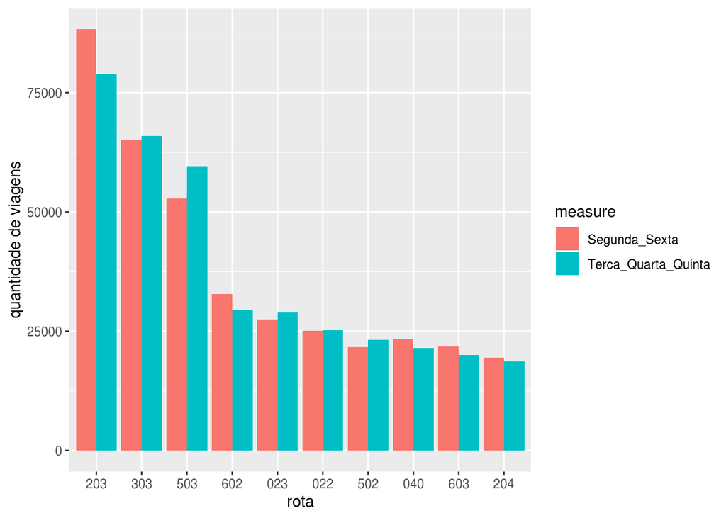

```r
data_comparation <- segunda_sexta %>%
  mutate(Segunda_Sexta = segunda_sexta$qntt, Terca_Quarta_Quinta = terça_quinta$qntt)

comp_long <- gather(data_comparation, key="measure", value="value", c("Segunda_Sexta", "Terca_Quarta_Quinta"))
comp_long <- comp_long %>% mutate(value_adjusted = value)

ggplot(comp_long, aes(fill = measure, x = reorder(route, -value_adjusted), y = value_adjusted)) + geom_col(position="dodge", stat='identity') + labs(x = "rota", y = "quantidade de viagens")
```

Como podemos ver, algumas rotas se destacam apresentando um número de viagens maior na mediana nos dias da semana de segunda e sexta em comparação com o período dos dias de terça a quinta, sendo elas a 203, 602 e 040. As duas últimas rotas ligam regiões periféricas da cidade a outras. Por outro lado, rotas como 303, segunda mais popular no geral, 503 e 023 apresentam uma maior quantidade de viagens no período de terça a quinta. Essas três rotas citadas ligam pontos da cidade ao Centro.

1.2) Distância percorrida

```r
day_group <- data.frame(week_day = c(2:6),
                        day_group = c("SS", "TQ", "TQ", "TQ", "SS"))

days <- estimated_trips_result %>%
  group_by(route, week_day) %>%
  summarise(dist = median(dist_median)) %>%
  merge(day_group) %>%
  group_by(day_group, route) %>%
  summarise(dist = median(dist))

segunda_sexta <- days %>%
  filter(day_group == "SS") %>%
  top_n(10)
terça_quinta <- days %>%
  filter(day_group == "TQ") %>%
  top_n(10)
```

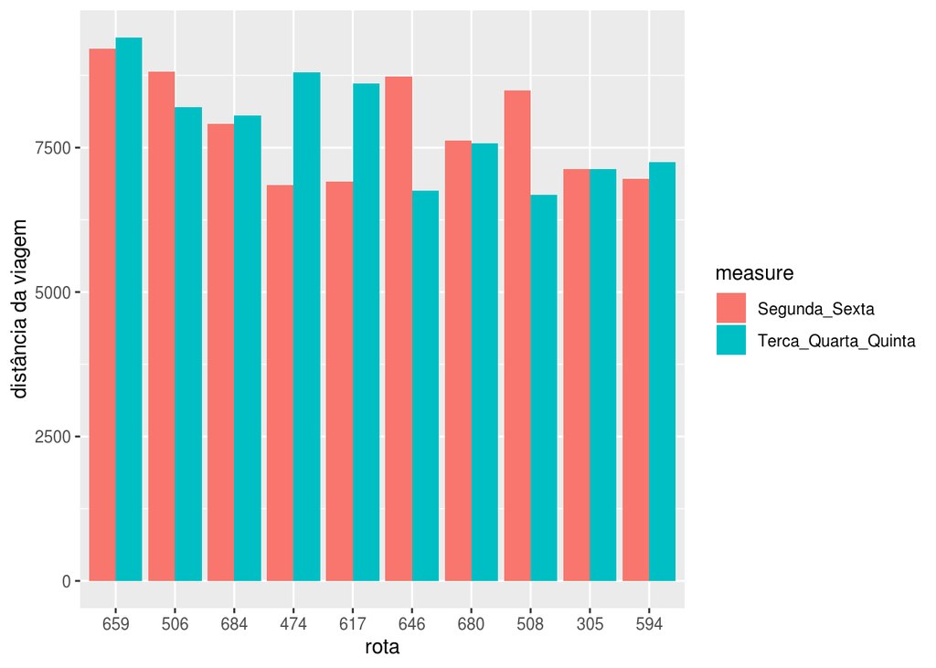

```r
data_comparation <- segunda_sexta %>%
  mutate(Segunda_Sexta = segunda_sexta$dist, Terca_Quarta_Quinta = terça_quinta$dist)

comp_long <- gather(data_comparation, key="measure", value="value", c("Segunda_Sexta", "Terca_Quarta_Quinta"))
comp_long <- comp_long %>% mutate(value_adjusted = value)

ggplot(comp_long, aes(fill = measure, x = reorder(route, -value_adjusted), y = value_adjusted)) + geom_col(position="dodge", stat='identity') + labs(x = "rota", y = "distância da viagem")
```

Observamos agora as rotas que na mediana percorrem uma maior distância. A rota 474 apresenta uma distância consideravalmente maior nas suas viagens no período de terça, quarta e quinta. A mesma liga regiões afastadas, como o bairro Uberaba, ao centro da cidade. Outra rota de comportamento similar é a 617. Essa liga também regiões afastadas, como o bairro Tutuquara, mas a bairros periféricos, como Capão Raso e Pinheirinho. Por outro lado, apresentando um comportamento contrário, ou seja, tendo a distância consideravelmente maior no período de segunda e sexta, a 646 liga uma bairro de características rurais a centros de comércio popular, como o bairro Pinheirinho.